# project

## STATISTICAL COMPUTING FINAL PROJECT

Team Members: Sravya Buridi, Bharath T, Mansoor Sheik, Manideep Unnamadala, Pavan Kumar manidi.

### Problem Statement:

The objective of this project is to explore the Regork dataset and identifying a potential area of growth where the company could invest future resources to increase revenue and profits.

The Complete journey provides access to data sets characterizing household level transactions over one year from a group of 2,469 households who are frequent shoppers at a grocery store:

### Importing data

```python
import pandas as pd
import numpy as np
import matplotlib.pyplot as plt
import datetime as dt
import seaborn as sns
from completejourney_py import get_data
from matplotlib.ticker import FuncFormatter
import warnings
import squarify
from functools import reduce
from datetime import datetime
data=get_data()
data.keys()
```

```
dict_keys(['campaign_descriptions', 'coupons', 'promotions', 'campaigns', 'demographics', 'transactions', 'coupon_redemptions', 'products'])
```

```python
transactions=data['transactions']
products=data['products']
demographics=data['demographics']
campaigns=data['campaigns']
coupon_sales = transactions.merge(products, on='product_id').query('coupon_disc != 0')
category_sales = coupon_sales.groupby('product_category').agg(total_sales=('sales_value', 'sum')).reset_index()
coupons=data['coupons']
campaign_descriptions = data['campaign_descriptions']
```

## Introduction to Analysis-1

### Analysis of percentage of sales for each household

By categorizing households according to their total sales in a year, it becomes possible to analyze the percentage of sales generated by each category of people. This provides a more nuanced understanding of consumer behavior and enables businesses to tailor their marketing strategies to specific segments of the population, ultimately leading to more effective targeting and increased revenue.

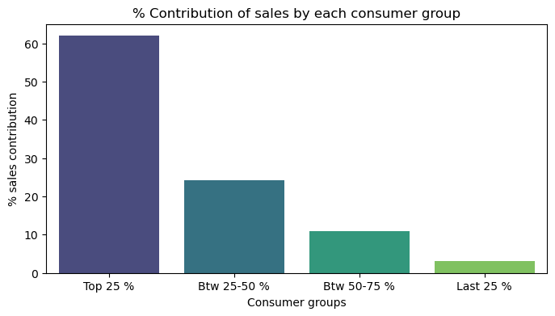

```python
household_summary = (transactions.groupby('household_id')
.agg({'sales_value': 'sum'})
.reset_index()
.rename(columns={'sales_value': 'overall_sales'})
.sort_values(by='overall_sales', ascending=False)
)

household_summary['check_value'] = 1
household_summary['cum_check_value'] = household_summary['check_value'].cumsum()
household_summary['perc_check_value'] = (household_summary['cum_check_value']*100/
household_summary['check_value'].sum())
conditions = [
household_summary['perc_check_value'] <= 25,
(household_summary['perc_check_value'] > 25) & (household_summary['perc_check_value'] <= 50),
(household_summary['perc_check_value'] > 50) & (household_summary['perc_check_value'] <= 75),
household_summary['perc_check_value'] > 75,
]
choices = ['Top 25 %', 'Btw 25-50 %', 'Btw 50-75 %', 'Last 25 %']
household_summary['quantile_groups'] = np.select(conditions, choices)

household_summary = (household_summary.groupby('quantile_groups')
.agg({'overall_sales': 'sum'})
.reset_index()
.sort_values(by='overall_sales', ascending=False)
)

household_summary['overall_sales_perc'] = (household_summary['overall_sales']*100/
household_summary['overall_sales'].sum())

plt.figure(figsize=(8, 4))
sns.barplot(x='quantile_groups', y='overall_sales_perc', data=household_summary,
palette='viridis')
plt.title('% Contribution of sales by each consumer group')
plt.xlabel('Consumer groups')
plt.ylabel('% sales contribution')
plt.show()
```

## Validation of the consumer segment at an month level:

Computed the overall sales for each household over the months Created quantile groups based on the overall sales over the months

```python
dt = get_data()
ts = dt['transactions']
# Create month_name column
ts['transaction_timestamp'] = pd.to_datetime(ts['transaction_timestamp'])
ts['month_name'] = ts['transaction_timestamp'].dt.month

household_sm = (ts.groupby(['household_id', 'month_name'])
.agg({'sales_value': 'sum'})
.reset_index()
.rename(columns={'sales_value': 'overall_sales'})
.sort_values(by='overall_sales', ascending=False)
)
```

```python
household_sm['check_vl'] = 1
household_sm['cum_check_vl'] = household_sm['check_vl'].cumsum()
household_sm['perc_check_vl'] = (household_sm['cum_check_vl']*100/
household_sm['check_vl'].sum())
conditions = [
household_sm['perc_check_vl'] <= 25,
(household_sm['perc_check_vl'] > 25) & (household_sm['perc_check_vl'] <= 50),
(household_sm['perc_check_vl'] > 50) & (household_sm['perc_check_vl'] <= 75),
household_sm['perc_check_vl'] > 75,
]
choices = ['Top 25 %', 'Btw 25-50 %', 'Btw 50-75 %', 'Last 25 %']
household_sm['quantile_gp'] = np.select(conditions, choices)
```

```python
household_sm.info()
```

```
<class 'pandas.core.frame.DataFrame'>
Int64Index: 24380 entries, 10025 to 443
Data columns (total 7 columns):
 #   Column         Non-Null Count  Dtype
---  ------         --------------  -----
 0   household_id   24380 non-null  int64
 1   month_name     24380 non-null  int64
 2   overall_sales  24380 non-null  float64
 3   check_vl       24380 non-null  int64
 4   cum_check_vl   24380 non-null  int64
 5   perc_check_vl  24380 non-null  float64
 6   quantile_gp    24380 non-null  object
dtypes: float64(2), int64(4), object(1)
memory usage: 1.5+ MB
```

```python
# Calculate household_monthly_summary
household_monthly_summary = (
    household_sm
    .groupby(['quantile_gp','month_name'])
    .agg(over_sales=('overall_sales', 'sum'))
    .reset_index()
    .sort_values(by=["month_name","over_sales"], ascending=False)
)



# Calculate overall_sales_perc
overall_sales_tl = household_monthly_summary['over_sales'].sum()
household_monthly_summary['over_sales_pc'] = household_monthly_summary['over_sales'] /overall_sales_tl * 100
```

```python
household_monthly_summary.head()
```

|  | quantile_gp | month_name | over_sales | over_sales_pc |
| --- | --- | --- | --- | --- |
| 47 | Top 25 % | 12 | 274032.44 | 5.962360 |
| 11 | Btw 25-50 % | 12 | 92220.56 | 2.006522 |
| 23 | Btw 50-75 % | 12 | 44867.65 | 0.976224 |
| 35 | Last 25 % | 12 | 10761.64 | 0.234150 |
| 46 | Top 25 % | 11 | 231979.50 | 5.047378 |

```python
mapping = {1: "January", 2: "February", 3: "March", 4: "April", 5: "May", 6: "June" , 7: "July", 8: "August", 9: "September", 10: "October" , 11: "November", 12: "December"}

# Replace the values in column month_name using the mapping
household_monthly_summary["month_name"] = household_monthly_summary["month_name"].replace(mapping)
```

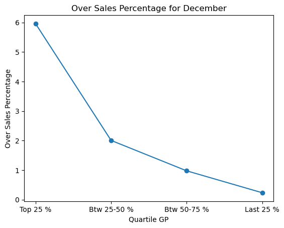

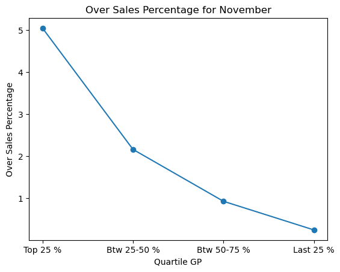

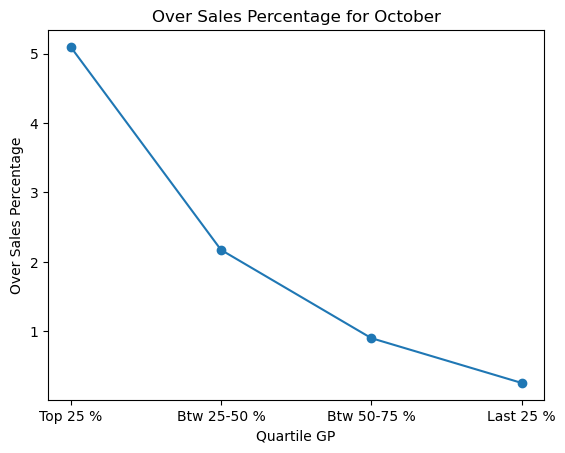

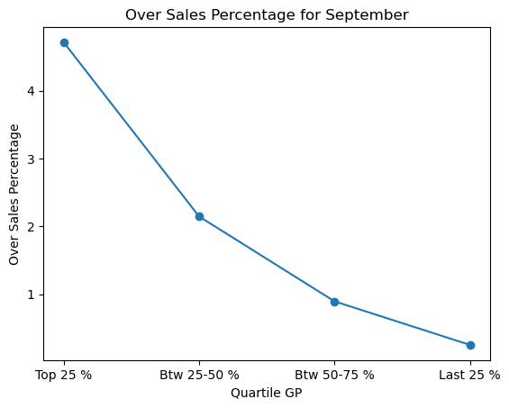

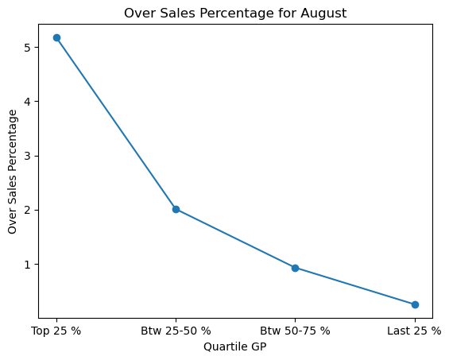

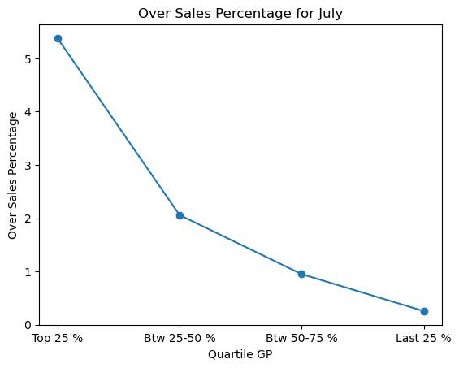

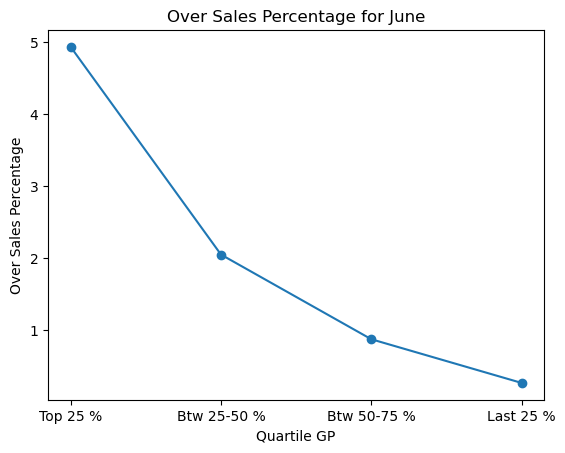

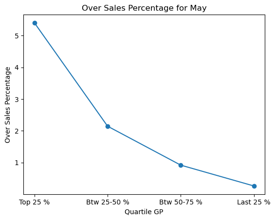

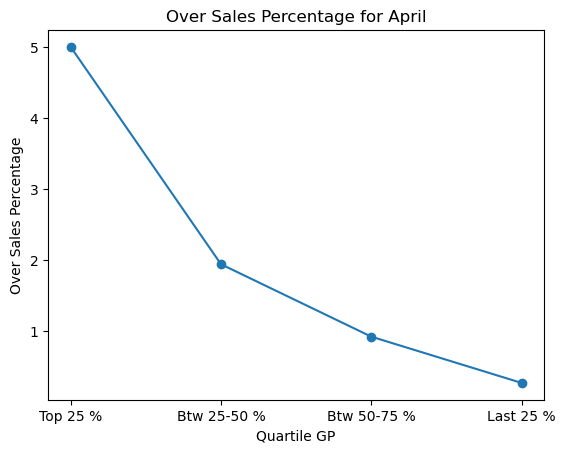

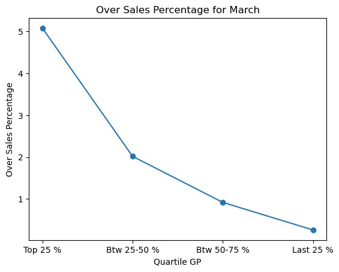

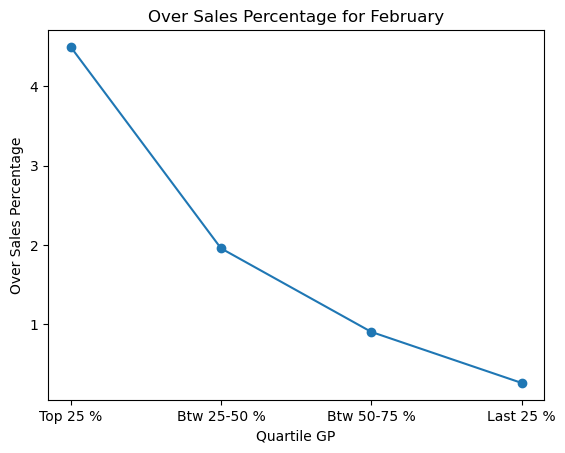

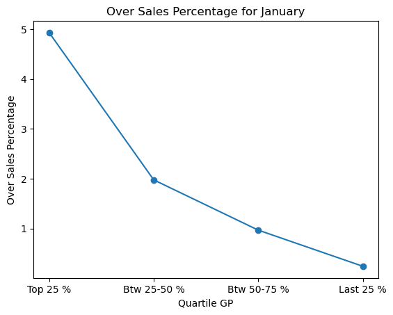

```python
# Extract unique month names from the data
months = household_monthly_summary["month_name"].unique()

# Loop over the months and create a separate plot for each month
for month in months:
    # Filter the data for the current month
    month_data = household_monthly_summary[household_monthly_summary["month_name"] == month]


    # Set up the plot
    plt.figure()
    plt.title(f"Over Sales Percentage for {month}")
    plt.xlabel("Quartile GP")
    plt.ylabel("Over Sales Percentage")

    # Plot the data for the current month
    plt.plot(month_data["quantile_gp"], month_data["over_sales_pc"], marker="o")

    # Show the plot
    plt.show()
```

#### So, we can say that these top 25% of consumers are important from the investment and marketing point of view

## Introduction to Analysis-2

**Here, we are analyzing the effectiveness of campaigns and coupons by doing Exploratory Data Analysis. We want to come up with insights/recommendations which will increases the coupon redemption and identifying the right products that customer might be interested in buying when there is a discount coupon available.**

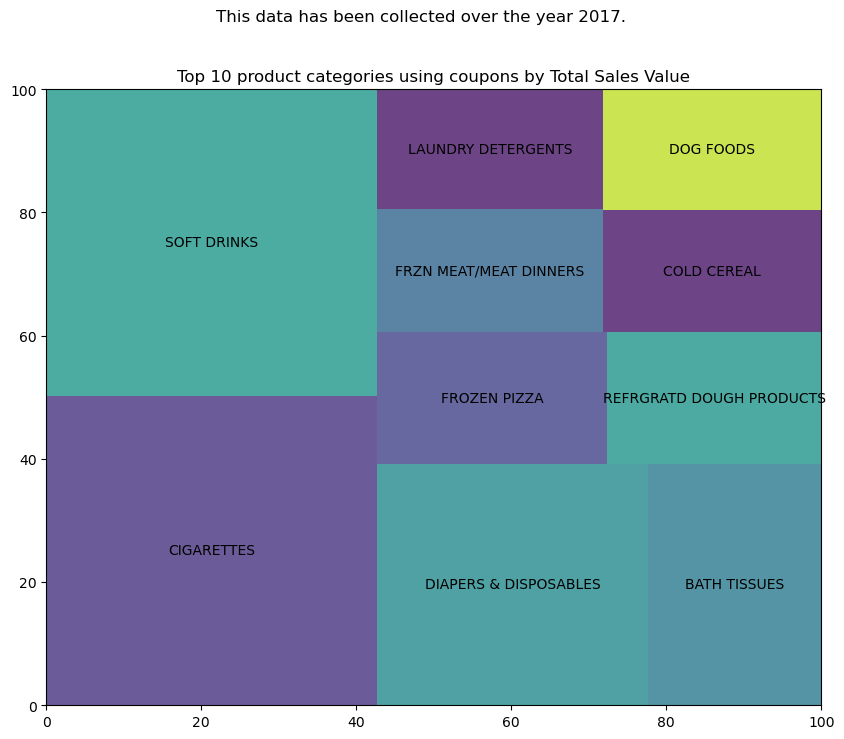

```python
category_sales = category_sales.sort_values('total_sales', ascending=False).head(10)

# Create plot
plt.figure(figsize=(10, 8))
squarify.plot(sizes=category_sales['total_sales'], label=category_sales['product_category'], alpha=.8)

# Add labels
plt.axis('on')
plt.title('Top 10 product categories using coupons by Total Sales Value')
plt.suptitle('This data has been collected over the year 2017.')
#plt.legend(["blue", "green"], loc ="lower right")

# Show plot
plt.show()
```

CIGARETTES, SOFT DRINKS, DIAPERS & DISPOSABLES, FROZEN PIZZA, REFRGRATD DOUGH PRODUCTS are few of the top products categories where more copouns were provided.

## Analysis on campaigns and products which are impacted through it

```python
# Inner join coupons, campaign_descriptions, and transactions tables
fa = pd.merge(coupons, campaign_descriptions, on='campaign_id', how='inner')
fa = pd.merge(fa, transactions, on='product_id', how='inner')

# Convert transaction_timestamp to date
fa['transaction_timestamp'] = pd.to_datetime(fa['transaction_timestamp'])

# Create match column
fa['match'] = (fa['transaction_timestamp'].between(fa['start_date'], fa['end_date'])).astype(int)

# Calculate total quantity sold without campaign and with campaign
l1 = fa.loc[fa['match'] == 0].groupby('product_id').agg(total_qunatity_sold_no_camp=('quantity', 'sum'))
l2 = fa.loc[fa['match'] == 1].groupby('product_id').agg(total_quantity_sold_camp=('quantity', 'sum'))

# Join the two tables and calculate Opportunity factor
joined = l1.join(l2).reset_index()
joined['Opportunity_factor'] = round((joined['total_quantity_sold_camp'] - joined['total_qunatity_sold_no_camp']) / joined['total_qunatity_sold_no_camp'], 2)

# Select top 10 products with highest Opportunity factor
top_10 = joined.nlargest(10, 'Opportunity_factor')

top_10
```

|  | product_id | total_qunatity_sold_no_camp | total_quantity_sold_camp | Opportunity_factor |
| --- | --- | --- | --- | --- |
| 21186 | 7442317 | 1 | 24.0 | 23.00 |
| 13347 | 1104146 | 2 | 43.0 | 20.50 |
| 31248 | 16805950 | 1 | 18.0 | 17.00 |
| 30965 | 15927327 | 1 | 15.0 | 14.00 |
| 12037 | 1071868 | 2 | 20.0 | 9.00 |
| 25647 | 12263016 | 2 | 20.0 | 9.00 |
| 31080 | 15973009 | 1 | 10.0 | 9.00 |
| 31288 | 17208470 | 3 | 29.0 | 8.67 |
| 31247 | 16805948 | 1 | 9.0 | 8.00 |
| 20040 | 6704447 | 4 | 34.0 | 7.50 |

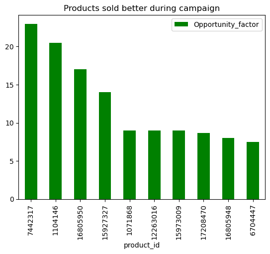

```python
# Plot bar chart
top_10
(
top_10
.plot.bar(title='Products sold better during campaign',color='green',x='product_id', y='Opportunity_factor')
.legend(loc='upper right')
);
```

**We can see that there are many products which were sold better when there is a campaign running on those products. These are products marketing team should target in the upcoming campaigns for better sales.**

```python
# joining the dataframes
fb = pd.merge(coupons, campaign_descriptions, on='campaign_id', how='inner')
fb = pd.merge(fb, transactions, on='product_id', how='inner')
```

```python
# convert transaction_timestamp to date format
fb['transaction_timestamp_nc'] = pd.to_datetime(fb['transaction_timestamp']).dt.date
```

```python
# calculate match column
fb['match_nc'] = ((fb['transaction_timestamp_nc'] < fb['start_date']) | (fb['transaction_timestamp_nc'] > fb['end_date'])).astype(int)
```

```python
# filter and group the dataframes
f1 = fb.loc[fb['match_nc'] == 0].groupby('product_id').agg(total_quantity_sold_camp=('quantity', 'sum')).reset_index()
f2 = fb.loc[fb['match_nc'] == 1].groupby('product_id').agg(total_quantity_sold_no_camp=('quantity', 'sum')).reset_index()
```

```python
# merge and calculate opportunity factor
result = pd.merge(f1, f2, on='product_id', how='inner')
result.head(6)
```

|  | product_id | total_quantity_sold_camp | total_quantity_sold_no_camp |
| --- | --- | --- | --- |
| 0 | 27479 | 3 | 7 |
| 1 | 27658 | 5 | 25 |
| 2 | 27754 | 4 | 24 |
| 3 | 28219 | 2 | 10 |
| 4 | 28267 | 1 | 3 |
| 5 | 28897 | 13 | 137 |

```python
result['Opportunity_factor_no_camp'] = round((result['total_quantity_sold_no_camp'] - result['total_quantity_sold_camp']) / result['total_quantity_sold_camp'], 2)
result
```

|  | product_id | total_quantity_sold_camp | total_quantity_sold_no_camp | Opportunity_factor_no_camp |
| --- | --- | --- | --- | --- |
| 0 | 27479 | 3 | 7 | 1.33 |
| 1 | 27658 | 5 | 25 | 4.00 |
| 2 | 27754 | 4 | 24 | 5.00 |
| 3 | 28219 | 2 | 10 | 4.00 |
| 4 | 28267 | 1 | 3 | 2.00 |
| ... | ... | ... | ... | ... |
| 19829 | 17242202 | 1 | 1 | 0.00 |
| 19830 | 17248393 | 4 | 4 | 0.00 |
| 19831 | 17284209 | 1 | 1 | 0.00 |
| 19832 | 17328748 | 1 | 1 | 0.00 |
| 19833 | 17330255 | 3 | 2 | -0.33 |

19834 rows × 4 columns

```python
top_10_non_campaign = result[result['Opportunity_factor_no_camp'] != float('inf')].sort_values('Opportunity_factor_no_camp', ascending=False).head(10)
top_10_non_campaign
```

|  | product_id | total_quantity_sold_camp | total_quantity_sold_no_camp | Opportunity_factor_no_camp |
| --- | --- | --- | --- | --- |
| 10380 | 1135476 | 5 | 1240 | 247.00 |
| 1598 | 846417 | 1 | 224 | 223.00 |
| 2363 | 870915 | 1 | 194 | 193.00 |
| 1432 | 841365 | 2 | 298 | 148.00 |
| 7527 | 1042021 | 1 | 149 | 148.00 |
| 4017 | 924262 | 1 | 134 | 133.00 |
| 2070 | 861821 | 3 | 399 | 132.00 |
| 15775 | 10312139 | 3 | 383 | 126.67 |
| 15202 | 9832538 | 1 | 122 | 121.00 |
| 9780 | 1116652 | 2 | 232 | 115.00 |

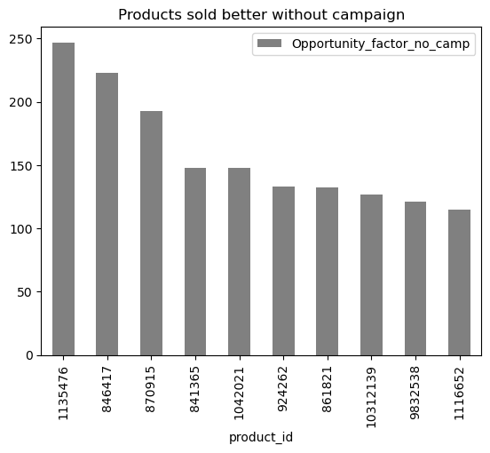

```python
# plot the data

top_10_non_campaign
(
top_10_non_campaign
.plot.bar(title='Products sold better without campaign',color='grey',x='product_id', y='Opportunity_factor_no_camp')
.legend(loc='upper right')
);
```

#### There are many products which had greater sales even without campaigning them. These products can have increased sales if campaigns includes these products

#### This coupons redemption and campaigns help marketing team to conlude which products should be campaigned for better sales.

## Introduction to Analysis-3

For this analysis, we are focusing on identifying demographics with a high sensitivity to campaigns or promotions for any discounted products. To accomplish this, we analysed the total sales for Regork as two parts: a)The first being total sales with respect to all of the different factors in demographics. b)The second was sales for only discounted items (all discounts like retail, coupon, coupon_match were considered for this analysis) While looking at these trends with respect to all the different factors, we noted some interesting insights, and only those were presented here to keep it concise. The general idea is that if the trend with demographics is different from total sales to discounted items sales,we can identify certain demographics whose sales are being affected because of the discounts placed on items.

### Data Preparation

Since each demographics has representation that varies in number, calculating the total sales to compare each demographics would not work in this case. So average sales for each demographic was looked at in our Analysis. we’ve calculated factors for each demographics, which will be used to calculate the respective Average sales. Since our focus was on Demographics, we will only be looking at transactions for which we have the demographics data.

```python
# demographics_income
demographics_income = demographics.groupby('income').size().reset_index(name='n')
demographics_income['income_factor'] = 1 / demographics_income['n']

# demographics_age
demographics_age = demographics.groupby('age').size().reset_index(name='n')
demographics_age['age_factor'] = 1 / demographics_age['n']

# demographics_kidscount
demographics_kidscount = demographics.groupby('kids_count').size().reset_index(name='n')
demographics_kidscount['kids_count_factor'] = 1 / demographics_kidscount['n']

# demographics_householdsize
demographics_householdsize = demographics.groupby('household_size').size().reset_index(name='n')
demographics_householdsize['household_size_factor'] = 1 / demographics_householdsize['n']

# demographics_maritalstatus
demographics_maritalstatus = demographics.groupby('marital_status').size().reset_index(name='n')
demographics_maritalstatus['marital_status_factor'] = 1 / demographics_maritalstatus['n']

# households_per_campaign
households_per_campaign = campaigns.groupby('campaign_id').size().reset_index(name='n')
households_per_campaign['households_per_campaign_factor'] = 1 / households_per_campaign['n']
```

### Analysis By income range

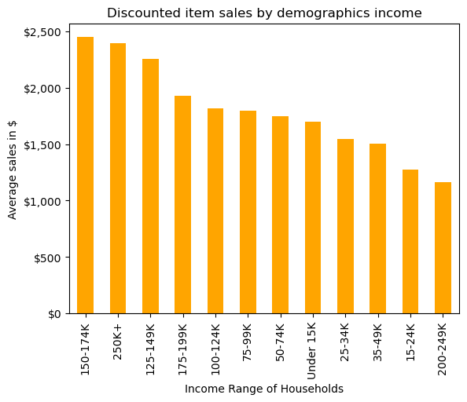

```python
filtered_transactions = transactions.loc[
    (transactions['retail_disc'] > 0) |
    (transactions['coupon_disc'] > 0) |
    (transactions['coupon_match_disc'] > 0)
]
merged = pd.merge(filtered_transactions, demographics, on='household_id')
sales_by_income = merged.groupby('income').agg(totalsales=('sales_value', 'sum'))

merged_income = pd.merge(sales_by_income, demographics_income, on='income')
merged_income['avgsales'] = merged_income['totalsales'] * merged_income['income_factor']
result = merged_income[['income', 'totalsales', 'avgsales']].sort_values(by='avgsales', ascending=False)

# Plotting
def format(x, _):
    return f'${x:,.0f}'

plt.figure(figsize=(10, 6))
ax = result.plot(kind='bar', x='income', y='avgsales', color='orange', legend=False)
ax.set_title('Discounted item sales by demographics income')
ax.set_ylabel('Average sales in $')
ax.set_xlabel('Income Range of Households')
ax.xaxis.set_tick_params(rotation=90)
ax.yaxis.set_major_formatter(FuncFormatter(format))
plt.show()
```

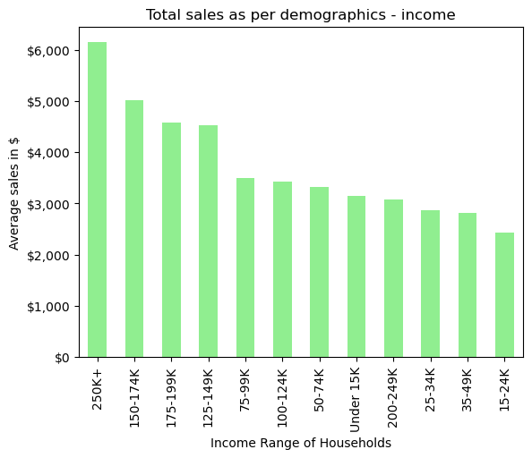

```python
merged = pd.merge(transactions, demographics, on='household_id')
sales_by_income = merged.groupby('income').agg(totalsales=('sales_value', 'sum'))

merged_income = pd.merge(sales_by_income, demographics_income, on='income')
merged_income['avgsales'] = merged_income['totalsales'] * merged_income['income_factor']
result = merged_income[['income', 'totalsales', 'avgsales']].sort_values(by='avgsales', ascending=False)

def format(x, _):
    return f'${x:,.0f}'

plt.figure(figsize=(10, 6))
ax = result.plot(kind='bar', x='income', y='avgsales', color='lightgreen', legend=False)
ax.set_title('Total sales as per demographics - income')
ax.set_ylabel('Average sales in $')
ax.set_xlabel('Income Range of Households')
ax.xaxis.set_tick_params(rotation=90)
ax.yaxis.set_major_formatter(FuncFormatter(format))
plt.show()
```

#### When comparing this trend in income groups, we seem to be seeing a lot of jumps in positions between different groups. This was the most change compared to the rest of the demographics. The 250+ although having the highest average sales in general, have little total sales and drop a position when looking at discounted items. This could be due to the high income in general, but there are various other income ranges that can be seen as sensitive to discounted items.

### Analysis By household size

```python
# filter rows where at least one discount is greater than 0
filtered = transactions[(transactions['retail_disc'] > 0) | (transactions['coupon_disc'] > 0) | (transactions['coupon_match_disc'] > 0)]

# join with demographics on household_id
joined = pd.merge(filtered, demographics, on='household_id', how='inner')

# group by household_size and calculate the sum of sales_value
grouped = joined.groupby('household_size').agg(totalsales=('sales_value', 'sum'))

# join with demographics_householdsize on household_size
joined2 = pd.merge(grouped, demographics_householdsize, on='household_size', how='inner')

# calculate avgsales as totalsales times household_size_factor
joined2['avgsales'] = joined2['totalsales'] * joined2['household_size_factor']

# select household_size, totalsales, and avgsales columns
selected = joined2[['household_size', 'totalsales', 'avgsales']]

# sort by descending avgsales
result = selected.sort_values(by='avgsales', ascending=False)

result
```

|  | household_size | totalsales | avgsales |
| --- | --- | --- | --- |
| 3 | 4 | 117852.80 | 2223.637736 |
| 4 | 5+ | 135951.69 | 2059.874091 |
| 2 | 3 | 197790.02 | 1814.587339 |
| 1 | 2 | 521599.69 | 1640.250597 |
| 0 | 1 | 384113.43 | 1506.327176 |

```python
# join the two dataframes by 'household_id'
joined_df = transactions.merge(demographics, on='household_id', how='inner')

# group by household_size and calculate the sum of sales_value
grouped_df = joined_df.groupby('household_size').agg(totalsales=('sales_value', 'sum')).reset_index()

# join 'grouped_df' with 'demographics_householdsize' dataframe
joined_df_2 = grouped_df.merge(demographics_householdsize, on='household_size', how='inner')

# calculate average sales and add as a new column 'avgsales'
joined_df_2['avgsales'] = joined_df_2['totalsales'] * joined_df_2['household_size_factor']

# select the desired columns
selected_df = joined_df_2[['household_size', 'totalsales', 'avgsales']]

# sort by descending order of 'avgsales'
sorted_df = selected_df.sort_values(by='avgsales', ascending=False)

sorted_df
```

|  | household_size | totalsales | avgsales |
| --- | --- | --- | --- |
| 3 | 4 | 207407.07 | 3913.340943 |
| 4 | 5+ | 255024.31 | 3864.004697 |
| 2 | 3 | 383256.15 | 3516.111468 |
| 1 | 2 | 1024643.15 | 3222.148270 |
| 0 | 1 | 754648.96 | 2959.407686 |

#### The average sales for the 5 and more household size is less compared to the households with 4 people.

### Analysis By Kids count

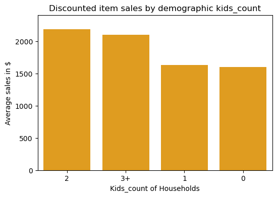

```python
df = transactions.loc[(transactions['retail_disc'] > 0) | (transactions['coupon_disc'] > 0) | (transactions['coupon_match_disc'] > 0)]
df = df.merge(demographics, on='household_id', how='inner')
df = df.groupby('kids_count').agg(totalsales=('sales_value', 'sum')).reset_index()
df = df.merge(demographics_kidscount, on='kids_count', how='inner')
df['avgsales'] = df['totalsales'] * df['kids_count_factor']
df = df[['kids_count', 'totalsales', 'avgsales']]
df = df.sort_values(by='avgsales', ascending=False)


plt.figure(figsize=(6, 4))
sns.barplot(x='kids_count', y='avgsales', data=df, color='orange')
plt.title('Discounted item sales by demographic kids_count')
plt.xlabel('Kids_count of Households')
plt.ylabel('Average sales in $')
plt.ylim([0, df['avgsales'].max() * 1.1])
# plt.yticks(np.arange(0, df['avgsales'].max() * 1.1, step=50000), labels=['${:,.0f}'.format(x) for x in np.arange(0, df['avgsales'].max() * 1.1, step=50000)])
# for index, row in df.iterrows():
#     plt.text(index, row['avgsales'] + 5000, '${:,.0f}'.format(row['totalsales']), ha='center', va='bottom', color='black')
plt.show()
```

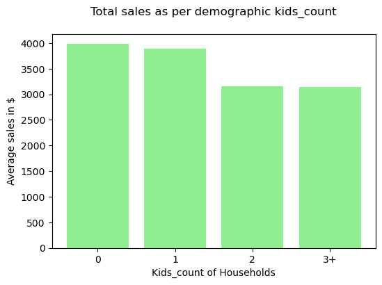

```python
# join transactions and demographics dataframes by household_id
df = pd.merge(transactions, demographics, on='household_id')

# group by kids_count and calculate total sales
df = df.groupby('kids_count').agg(totalsales=('sales_value', 'sum')).reset_index()

# join demographics_kidscount dataframe to df
df = pd.merge(df, demographics_kidscount, on='kids_count')

# calculate average sales
df['avgsales'] = df['totalsales'] * df['kids_count_factor']

# select and order columns
df = df[['kids_count', 'totalsales', 'avgsales']]
df = df.sort_values('avgsales', ascending=False)

fig, ax = plt.subplots(figsize=(6,4))

ax.bar(df['kids_count'], df['avgsales'], color='lightgreen')
ax.set_xlabel('Kids_count of Households')
ax.set_ylabel('Average sales in $')
ax.set_title('Total sales as per demographic kids_count\n')
ax.set_ylim(bottom=0)

plt.xticks(df.index, df['kids_count'])
plt.xticks(rotation=0)

plt.show()
```

## Summary:

• So, we can say that these top 25% of consumers are important from the investment and marketing point of view

• CIGARETTES, SOFT DRINKS, DIAPERS & DISPOSABLES, FROZEN PIZZA, REFRGRATD DOUGH PRODUCTS are few of the top products categories where more copouns were provided.

• There are many products which had greater sales even without campaigning them. These products can have increased sales if campaigns includes these products

• This coupons redemption and campaigns help marketing team to conlude which products should be campaigned for better sales.